# A Titanic Exploration

## Demo: Histogram Fare

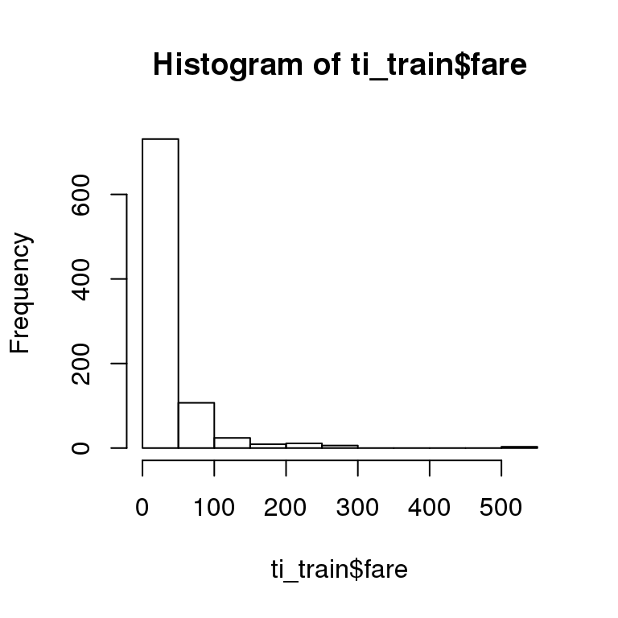

```r
## Returns a histogram passengers fare costs.
## Basic usage is easy and intuitive.
## You aren't going to publish this. But it is useful EDA.
hist(ti_train$fare)
```

## Practice: Histogram Age

```r
## Q1: Create a histogram chart showing the age of passengers.
##
##
```

## "Fun" Facts About Titanic

- Titanic disembarked on her maiden voyage with roughly 1,317 passengers.
  - *Was Jack Dawson one of them????*
- Titanic was designed for a max 2,566 passengers.
- This tragedy could have been **much** worse.

## Questions:

- What proportion of passengers died?
- How can we identify factors which correlate with passenger survival?

## Survival

The `survived` column is numerical, but categorical.

```r
## Returns a row contingency table of the survived column.
## Remember: 1 == Yes, 0 == No
survival <- table( ti_train$survived )
survival
```

```
##
##   0   1
## 549 342
```

- The odds of surviving? Not good.
- 0 and 1 is hard to read. We can do better.
- But, we'll want to keep this for the logistic regression.

## Demo: Lived

We can create an easier to read column.

```r
## Creates a new column, "lived" and fills it in.
## First, create a new column with NA data in it.
## Then, fill in the values you want.
ti_train$lived <- NA
ti_train$lived[ ti_train$survived == 1 ] <- "Yes"
ti_train$lived[ ti_train$survived == 0 ] <- "No"

## Returns a contingency table of the new lived column.
lived <- table( ti_train$lived )
lived
```

```
##
##  No Yes
## 549 342
```

## Lived Proportions

```r
## Creates a contingency table with proportions.
## This is similar to how it is done in SQL.
prc_lived <- round( 100*prop.table( lived ), 2 )
prc_lived
```

```
##
##    No   Yes
## 61.62 38.38
```

- Fewer than 40% of passenger survived.

## Demo: Lived BarPlot

```r
## Plots the lived proportions. Now fancier!
## Reverses Yes and No
## Labels the graph and the axes.
## Colors Output
## And adjusts the Y limit.
barplot(sort(prc_lived, decreasing=FALSE),
        main="Proportion of Titanic Passengers Who Lived",
        xlab="Lived?",
        ylab="Percent of Passengers",
        col="darkblue",
        ylim=c(0,100)
        )
```

- If we increase the code complexity.
- We are rewarded with more sophisticated output.

## Demo: Lived BarPlot

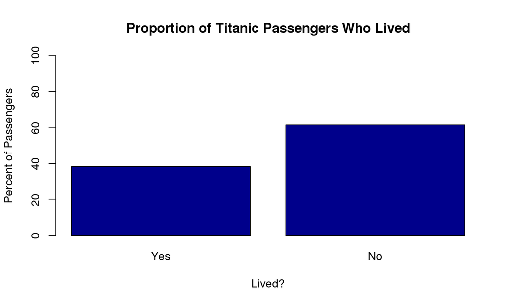

## Hypothesis Testing

## Hypothesis

- When someone says the name "Titanic" most of us think of the infamous phrase "women and children first".
- But, did it matter?

#### Formal Hypotheses:

- Children were more likely to survive than adults.
- Females more likely to survive than males.

## Children More Likely To Survive

```r
## Creates a new column, "child" and fills it in.
ti_train$child <- NA
ti_train$child[ ti_train$age <= 18 ] <- "Child"
ti_train$child[ ti_train$age > 18 ] <- "Adult"


## Returns a 2x2 contingency table.
child_survival <- table( ti_train$child,ti_train$lived )
child_survival
```

```
##
##          No Yes
##   Adult 355 220
##   Child  69  70
```

## Children Survival Proportions

```r
## Proportion of children and adults who survived.
## Margin = 1 because 1 == ROWS, 2 == COLUMNS. ALWAYS
prop.table(child_survival, margin=1)
```

```
##
##                No       Yes
##   Adult 0.6173913 0.3826087
##   Child 0.4964029 0.5035971
```

- It seems likely that yes, children were more likely to survive.

## Children Survival Significance

```r
## Hypothesis: Children are more likely to survive.
## Run prop.test against the values, NOT the proportions.
prop.test(child_survival, alternative = "greater")
```

```
##
##  2-sample test for equality of proportions with continuity
##  correction
##
## data:  child_survival
## X-squared = 6.3013, df = 1, p-value = 0.006032
## alternative hypothesis: greater
## 95 percent confidence interval:
##  0.03920865 1.00000000
## sample estimates:
##    prop 1    prop 2
## 0.6173913 0.4964029
```

- The p-value is less that 0.05, so we can reject the null hypothesis.
- Yes children were more likely to survive.
- When passed a contingency table, R will calculate greater/less based on the FIRST COLUMN. Adjust your hypothesis accordingly.

## Summary

```r
## The summary() function can be used
## to examine most R objects.
summary(child_survival)
```

```
## Number of cases in table: 714
## Number of factors: 2
## Test for independence of all factors:
##  Chisq = 6.794, df = 1, p-value = 0.009148
```

- The summary() command tests for independence.
- Try this command on `ti_train`.
- What do you see? Is it useful?

## Mosaic Plot

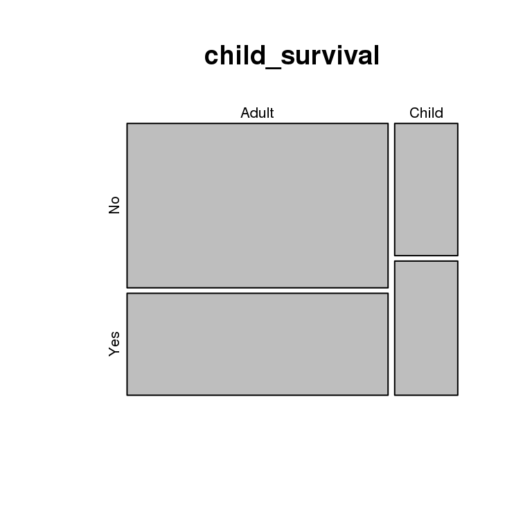

```r
## The mosaicplot is another way of visualizing
## complex relationships and can scale effectively
## for many variables.
mosaicplot(child_survival)
```

- You cannot use this for testing independence.
- But it can be a useful visualization tool.

## Practice: Sex & Survival

```r
## Q1: Create a 2x2 Contingency table for Lived and Sex.
##     Call it sex_survival.


## Q2: What is the proportion of men who lived, compared to
##     proportion of women?


## Q3: Is the observed difference between the sexes in the
##     survival rate statistically significant?
##
```